# HW3

Author

Yi Wang

## Setup

```r
library(tidyverse)
library(tidytext)
library(textdata)
library(ggplot2)
library(knitr)
library(kableExtra)
```

## Load-data

```r
pubmed <- readr::read_csv("~/Desktop/pubmed.csv", show_col_types = FALSE)
```

## clean data

```r
pubmed_clean <- pubmed %>%
  mutate(
    abstract_id = row_number(),          # give each abstract a unique id
    term = str_squish(term),             # remove extra spaces in term
    abstract = str_squish(abstract)      # remove extra spaces in abstract
  ) %>%
  filter(!is.na(abstract), abstract != "")   # remove empty or missing abstracts
```

# Text Mining

## 1. (15 points) How many abstracts are associated with each search term? Tokenize the abstracts and count the number of each token. Do you see anything interesting? What are the 5 most common tokens for each search term?

```r
#Tokenize (split abstracts into words)
tokens <- pubmed_clean %>%
  unnest_tokens(word, abstract) %>%
  filter(!str_detect(word, "^[0-9]+$"))
#Count number of abstracts per search term
abstract_counts <- pubmed_clean %>%
  count(term, name = "n_abstracts")
abstract_counts
```

```
# A tibble: 5 × 2
  term            n_abstracts
  <chr>                 <int>
1 covid                   981
2 cystic fibrosis         376
3 meningitis              317
4 preeclampsia            780
5 prostate cancer         787
```

```r
#Word count per term
term_word_counts <- tokens %>%
  count(term, word, sort = TRUE)
#Top 5 most common words per term
top5_q1 <- term_word_counts %>%
  group_by(term) %>%
  slice_max(n, n = 5) %>%
  ungroup()

top5_q1
```

```
# A tibble: 25 × 3
   term            word      n
   <chr>           <chr> <int>
 1 covid           the    9741
 2 covid           of     7668
 3 covid           covid  7275
 4 covid           and    6861
 5 covid           in     4526
 6 cystic fibrosis the    2677
 7 cystic fibrosis of     2304
 8 cystic fibrosis and    1777
 9 cystic fibrosis in     1497
10 cystic fibrosis to     1011
# ℹ 15 more rows
```

A total of five search terms were analyzed. The number of abstracts retrieved for each term is as follows: covid: 981 abstracts, cystic fibrosis: 376 abstracts, meningitis: 317 abstracts, preeclampsia: 780 abstracts, prostate cancer: 787 abstracts. COVID has the largest number of abstracts (981), likely reflecting the surge of related research after the global pandemic. Meningitis and cystic fibrosis have comparatively fewer abstracts, which makes sense as they are more specific or less frequently studied diseases.

After tokenizing all abstracts into individual words, the most frequent tokens for each search term were:

covid: the, of, covid, and, in

cystic fibrosis: the, of, and, in, to

meningitis: the, of, and, in, a

preeclampsia: the, of, and, in, to

prostate cancer: the, of, and, cancer, prostate

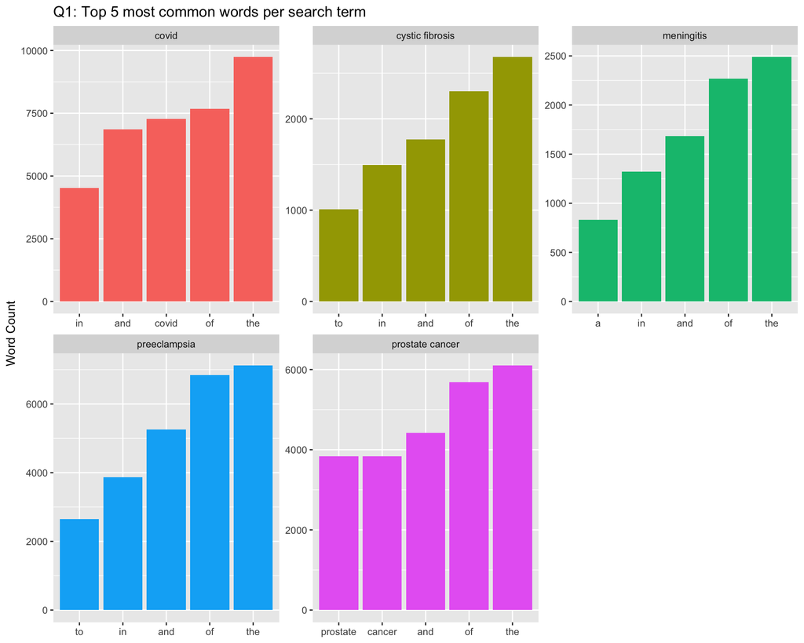

```r
#Visualization
top5_q1 %>%
  ggplot(aes(x = reorder_within(word, n, term), y = n, fill = term)) +
  geom_col(show.legend = FALSE) +
  facet_wrap(~term, scales = "free") +
  scale_x_reordered() +
  labs(title = "Q1: Top 5 most common words per search term",
       x = NULL, y = "Word Count")
```

Most of the top words are common English stop words (the, of, and, in), which are not informative for biomedical interpretation. However, several disease-specific tokens such as covid, cancer, and prostate also appear among the top five, confirming that the search results are relevant to each medical topic.

## 2. (15 points) Does removing stop words change what tokens appear as the most frequent? What are the 5 most common tokens for each search term after removing stop words?

```r
data("stop_words")
# remove stop words from tokenized data
tokens_nostop <- tokens %>%
  anti_join(stop_words, by = c("word" = "word"))
# count word frequency
term_word_counts_nostop <- tokens_nostop %>%
  count(term, word, sort = TRUE)
# top 5 words per term after removing stop words
top5_q2 <- term_word_counts_nostop %>%
  group_by(term) %>%
  slice_max(n, n = 5) %>%
  ungroup()

top5_q2
```

```
# A tibble: 26 × 3
   term            word            n
   <chr>           <chr>       <int>
 1 covid           covid        7275
 2 covid           patients     2293
 3 covid           disease       943
 4 covid           pandemic      800
 5 covid           coronavirus   647
 6 covid           health        647
 7 cystic fibrosis fibrosis      867
 8 cystic fibrosis cystic        862
 9 cystic fibrosis cf            625
10 cystic fibrosis patients      586
# ℹ 16 more rows
```

After removing English stop words such as the, of, and, in, and to, the most frequent tokens changed substantially. Instead of generic language words, the top tokens now reflect disease-specific and biomedical terminology. The five most common tokens for each search term are as follows:

covid: covid, patients, disease, pandemic, coronavirus

cystic fibrosis: fibrosis, cystic, cf, patients, disease

meningitis: patients, meningitis, meningeal, csf, clinical

preeclampsia: pre, eclampsia, preeclampsia, women, pregnancy

prostate cancer: cancer, prostate, patients, treatment, disease

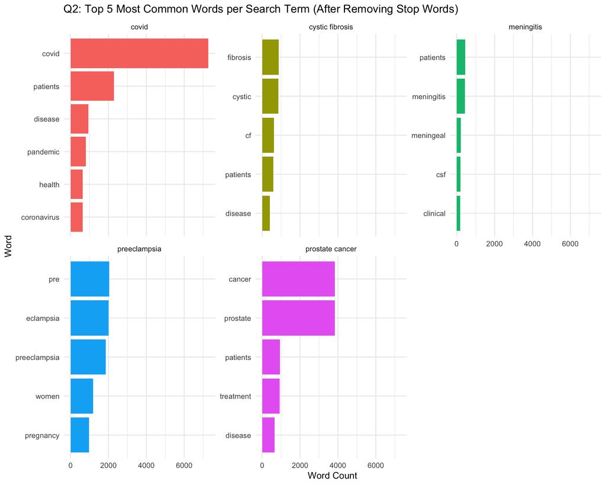

```r
#Visualization
top5_q2 %>%
  ggplot(aes(x = reorder_within(word, n, term), y = n, fill = term)) +
  geom_col(show.legend = FALSE) +
  facet_wrap(~term, scales = "free_y") +
  scale_x_reordered() +
  coord_flip() +
  labs(
    title = "Q2: Top 5 Most Common Words per Search Term (After Removing Stop Words)",
    x = "Word",
    y = "Word Count"
  ) +
  theme_minimal()
```

Removing stop words significantly improves interpretability — the top words now clearly relate to the medical context of each topic. Each search term highlights its key disease entity (covid, cystic fibrosis, meningitis, preeclampsia, prostate cancer). The frequent presence of words like patients, treatment, clinical, and disease indicates a focus on patient care and disease management across abstracts. Compared with Q1, where the top words were dominated by the, of, and and, this filtered list captures the scientific content of each topic more accurately.

## 3. (10 points)Tokenize the abstracts into bigrams. Find the 10 most common bigrams and visualize them.

```r
bigrams <- pubmed_clean %>%
  unnest_tokens(bigram, abstract, token = "ngrams", n = 2)
# Count frequency of each bigram
bigram_counts <- bigrams %>%
  count(bigram, sort = TRUE)
# Show the top 10 most frequent bigrams
top10_bigrams <- bigram_counts %>%
  slice_max(n, n = 10)
top10_bigrams
```

```
# A tibble: 10 × 2
   bigram              n
   <chr>           <int>
 1 covid 19         6969
 2 of the           3883
 3 in the           3418
 4 prostate cancer  3222
 5 pre eclampsia    1854
 6 patients with    1587
 7 of covid         1519
 8 and the          1154
 9 to the           1061
10 of prostate       870
```

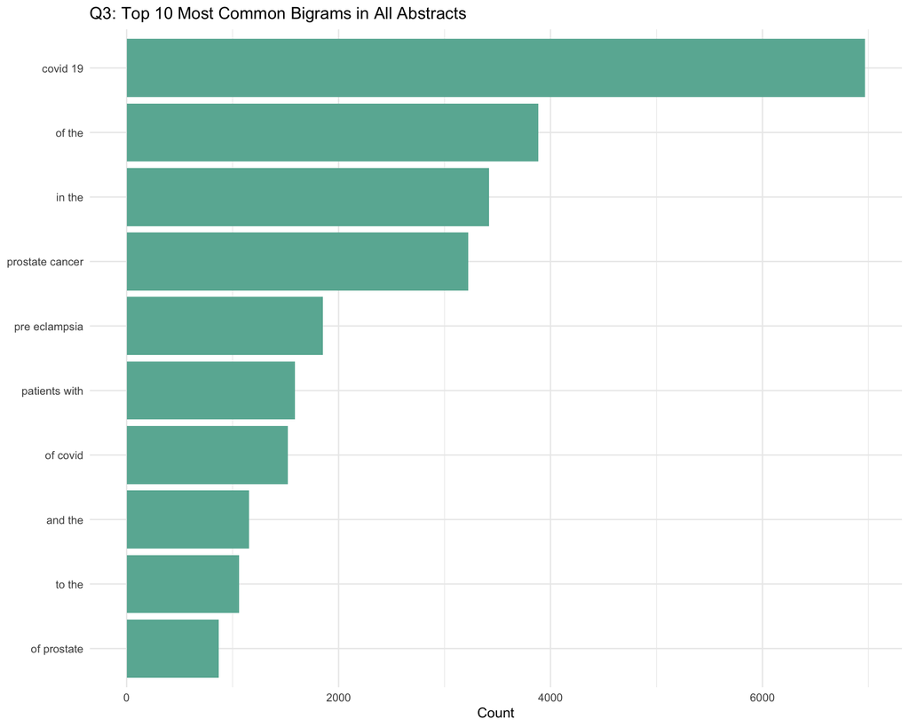

```r
#Visualization
top10_bigrams %>%
  ggplot(aes(x = reorder(bigram, n), y = n)) +
  geom_col(fill = "#69b3a2") +
  coord_flip() +
  labs(
    title = "Q3: Top 10 Most Common Bigrams in All Abstracts",
    x = NULL,
    y = "Count"
  ) +
  theme_minimal()
```

The visualization clearly shows topic-specific bigrams (covid 19, prostate cancer, pre eclampsia) dominating the abstracts, while common linguistic structures (of the, in the, and the) remain frequent due to typical scientific writing style. Removing stop-word bigrams in later analyses could further emphasize biomedical content and disease-specific relationships.

## 4. (20 points) Calculate the TF-IDF value for each word-search term combination (here you want the search term to be the “document”). What are the 5 tokens from each search term with the highest TF-IDF value? How are the results different from the answers you got in Question 1?

```r
# Here, "term" acts as the document, and each word's importance is measured by tf-idf
tfidf_data <- tokens_nostop %>%
  count(term, word, sort = TRUE) %>%
  bind_tf_idf(word, term, n) %>%
  arrange(desc(tf_idf))
# Top 5 words per term with highest TF-IDF
top5_tfidf <- tfidf_data %>%
  group_by(term) %>%
  slice_max(tf_idf, n = 5) %>%
  ungroup() %>%
  mutate(tf_idf = round(tf_idf, 4))
top5_tfidf
```

```
# A tibble: 25 × 6
   term            word            n      tf   idf tf_idf
   <chr>           <chr>       <int>   <dbl> <dbl>  <dbl>
 1 covid           covid        7275 0.0722  1.61  0.116
 2 covid           pandemic      800 0.00794 1.61  0.0128
 3 covid           coronavirus   647 0.00642 1.61  0.0103
 4 covid           sars          372 0.00369 1.61  0.0059
 5 covid           cov           334 0.00331 1.61  0.0053
 6 cystic fibrosis cf            625 0.0242  0.916 0.0222
 7 cystic fibrosis fibrosis      867 0.0336  0.511 0.0172
 8 cystic fibrosis cystic        862 0.0334  0.511 0.0171
 9 cystic fibrosis cftr           86 0.00333 1.61  0.0054
10 cystic fibrosis sweat          83 0.00321 1.61  0.0052
# ℹ 15 more rows
```

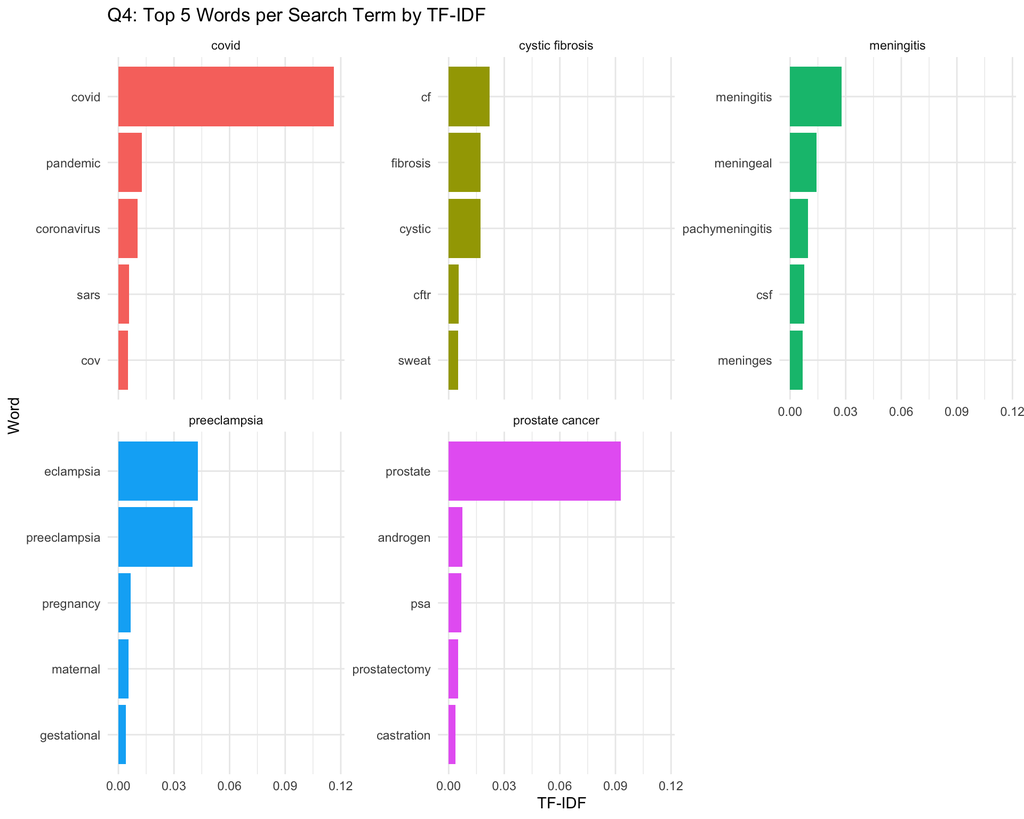

```r
#Visualization
top5_tfidf %>%
  ggplot(aes(x = reorder_within(word, tf_idf, term), y = tf_idf, fill = term)) +
  geom_col(show.legend = FALSE) +
  facet_wrap(~term, scales = "free_y") +
  scale_x_reordered() +
  coord_flip() +
  labs(
    title = "Q4: Top 5 Words per Search Term by TF-IDF",
    x = "Word",
    y = "TF-IDF"
  ) +
  theme_minimal()
```

After calculating the TF–IDF (Term Frequency–Inverse Document Frequency) values for each word–search term combination, we found that the top tokens for each disease were highly specific to their respective topics. For example, the highest TF–IDF words for *covid were covid, pandemic, coronavirus, sars, and cov; for cystic fibrosis, the top tokens included cf, fibrosis, cystic, cftr, and sweat; for meningitis, they were meningitis, meningeal, pachymeningitis, csf, and meninges; for preeclampsia, the most distinctive terms were eclampsia, preeclampsia, pregnancy, maternal, and gestational; and for prostate cancer, the top tokens were prostate, androgen, psa, prostatectomy, and castration*.

Compared with Question 1, where the most common words were general stop words such as the, of, and and, the TF–IDF analysis highlights more meaningful and disease-specific vocabulary. This demonstrates that TF–IDF is effective at identifying the most informative and unique biomedical terms associated with each research topic, rather than simply ranking by raw word frequency.

# Sentiment Analysis

## 5. (20 points) Perform a sentiment analysis using the NRC lexicon. What is the most common sentiment for each search term? What if you remove `"positive"` and `"negative"`from the list?

```r
# Load NRC sentiment lexicon
nrc <- get_sentiments("nrc")

# Join NRC lexicon with our tokenized data (no stop words)
nrc_sent <- tokens_nostop %>%
  inner_join(nrc, by = c("word" = "word"))

# Count sentiment occurrences per search term
nrc_counts <- nrc_sent %>%
  count(term, sentiment, sort = TRUE)

# Show the most common sentiment for each search term
nrc_top <- nrc_counts %>%
  group_by(term) %>%
  slice_max(n, n = 1) %>%
  ungroup()

nrc_top
```

```
# A tibble: 5 × 3
  term            sentiment     n
  <chr>           <chr>     <int>
1 covid           positive   9254
2 cystic fibrosis positive   2564
3 meningitis      negative   1959
4 preeclampsia    positive   7603
5 prostate cancer negative   8799
```

```r
# Remove "positive" and "negative" sentiments
nrc_counts_no_pn <- nrc_sent %>%
  filter(!sentiment %in% c("positive", "negative")) %>%
  count(term, sentiment, sort = TRUE)

# Get most common sentiment for each term
nrc_top_no_pn <- nrc_counts_no_pn %>%
  group_by(term) %>%
  slice_max(n, n = 1) %>%
  ungroup()

nrc_top_no_pn
```

```
# A tibble: 5 × 3
  term            sentiment        n
  <chr>           <chr>        <int>
1 covid           fear          7373
2 cystic fibrosis disgust       1714
3 meningitis      fear          1371
4 preeclampsia    anticipation  4555
5 prostate cancer fear          8039
```

Using the NRC sentiment lexicon, we analyzed the emotional tone of each abstract by search term. The most common overall sentiments (including *positive* and *negative*) were as follows:  
covid (positive, 9254), cystic fibrosis (positive, 2564), meningitis (negative, 1959), preeclampsia (positive, 7603), and prostate cancer (negative, 8799).  
This suggests that most topics, particularly *covid*, *preeclampsia*, and *cystic fibrosis*, contain a higher number of words associated with positive sentiment, while *meningitis* and *prostate cancer* are dominated by negative expressions, likely due to their severe clinical context.

When the categories *“positive”* and *“negative”* were removed to focus on more specific emotions, the most common sentiments shifted to:  
covid (fear, 7373), cystic fibrosis (disgust, 1714), meningitis (fear, 1371), preeclampsia (anticipation, 4555), and prostate cancer (fear, 8039).

These results reveal more nuanced emotional tones in biomedical writing: fear dominates infectious and life-threatening conditions such as *covid*, *meningitis*, and *prostate cancer*; *anticipation* appears in *preeclampsia*, possibly reflecting research around prevention and pregnancy outcomes; and *disgust* is associated with *cystic fibrosis*, potentially reflecting descriptions of chronic disease burden.

In summary, the NRC lexicon highlights clear emotional differences across disease topics. While overall positivity or negativity gives a broad tone, removing those general categories uncovers specific emotional undercurrents that align with the medical and psychological aspects of each condition.

## 6. (20 points) Now perform a sentiment analysis using the AFINN lexicon to get an average positivity score for each abstract (hint: you may want to create a variable that indexes, or counts, the abstracts). Create a visualization that shows these scores grouped by search term. Are any search terms noticeably different from the others?

```r
# Load AFINN lexicon
afinn <- get_sentiments("afinn")

# Add unique abstract IDs for grouping
pubmed2 <- pubmed_clean %>%
  mutate(abstract_id = row_number())

# Tokenize abstracts and join with AFINN
afinn_scored <- pubmed2 %>%
  unnest_tokens(word, abstract) %>%
  inner_join(afinn, by = c("word" = "word"))

# Calculate average sentiment score per abstract
abstract_scores <- afinn_scored %>%
  group_by(term, abstract_id) %>%
  summarise(mean_score = mean(value), .groups = "drop")

# View results
head(abstract_scores)
```

```
# A tibble: 6 × 3
  term  abstract_id mean_score
  <chr>       <int>      <dbl>
1 covid           1     -1.13
2 covid           2     -2
3 covid           3      0.214
4 covid           4     -0.8
5 covid           5     -1.67
6 covid           6     -0.143
```

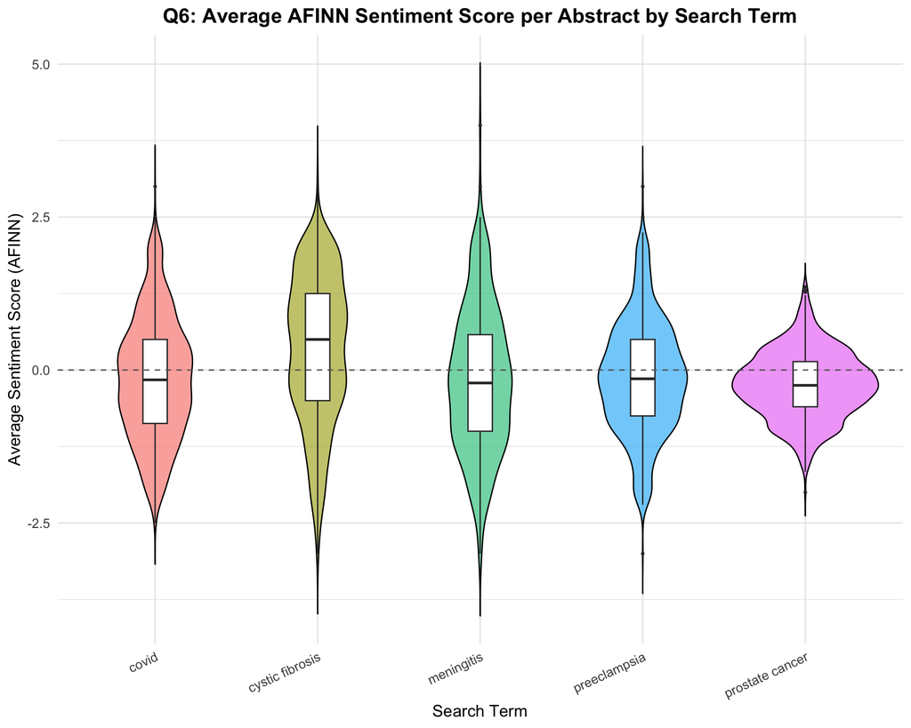

```r
# ---- Visualization: Violin Plot ----
ggplot(abstract_scores, aes(x = term, y = mean_score, fill = term)) +
  geom_violin(trim = FALSE, alpha = 0.6, color = "black") +
  geom_boxplot(width = 0.15, fill = "white", outlier.shape = 16, outlier.size = 1) +
  geom_hline(yintercept = 0, linetype = "dashed", color = "gray40") +
  labs(
    title = "Q6: Average AFINN Sentiment Score per Abstract by Search Term",
    x = "Search Term",
    y = "Average Sentiment Score (AFINN)"
  ) +
  theme_minimal(base_size = 13) +
  theme(
    legend.position = "none",
    plot.title = element_text(size = 16, face = "bold", hjust = 0.5),
    axis.text.x = element_text(angle = 25, hjust = 1)
  )
```

Using the AFINN lexicon, each abstract was assigned sentiment values ranging from –5 (very negative) to +5 (very positive), and the average score per abstract was calculated. The distribution of these mean scores by search term is shown in the violin plot above.

Overall, the average sentiment scores across all abstracts were close to zero, indicating that most biomedical abstracts are written in a neutral tone. However, subtle differences were observed between topics. Abstracts related to prostate cancer and meningitis tended to have slightly more negative sentiment, reflecting the serious and often life-threatening nature of these diseases. In contrast, cystic fibrosis showed somewhat more positive, possibly due to a stronger focus on research progress, treatment development, or patient management.

The AFINN analysis therefore reveals nuanced differences in emotional tone across medical research topics that are not captured by simple word frequency counts.